# $CA\color{red}4$

### $\color{red}{Borna} \hspace{3pt} Tavasoli - 810198374$

import default libraries:

```python
import pandas, numpy, string
```

## $Part \hspace{3pt} \color{green}{Zero}:$

```python
dataframe = pandas.read_csv("dataset.csv")
print(dataframe.describe())
```

```
       release_year
count  11059.000000
mean    2014.209603
std        8.959517
min     1925.000000
25%     2013.000000
50%     2017.000000
75%     2019.000000
max     2021.000000
```

```python
dataframe
```

|  | type | title | cast | country | release_year | listed_in | description |
| --- | --- | --- | --- | --- | --- | --- | --- |
| 0 | Movie | Dick Johnson Is Dead | NaN | United States | 2020 | Documentaries | As her father nears the end of his life, filmm... |
| 1 | TV Show | Blood & Water | Ama Qamata, Khosi Ngema, Gail Mabalane, Thaban... | South Africa | 2021 | International TV Shows, TV Dramas, TV Mysteries | After crossing paths at a party, a Cape Town t... |
| 2 | TV Show | Ganglands | Sami Bouajila, Tracy Gotoas, Samuel Jouy, Nabi... | NaN | 2021 | Crime TV Shows, International TV Shows, TV Act... | To protect his family from a powerful drug lor... |
| 3 | TV Show | Jailbirds New Orleans | NaN | NaN | 2021 | Docuseries, Reality TV | Feuds, flirtations and toilet talk go down amo... |
| 4 | TV Show | Kota Factory | Mayur More, Jitendra Kumar, Ranjan Raj, Alam K... | India | 2021 | International TV Shows, Romantic TV Shows, TV ... | In a city of coaching centers known to train I... |
| ... | ... | ... | ... | ... | ... | ... | ... |
| 11054 | TV Show | X-Men: Evolution | Noel Fisher, Vincent Gale, Christopher Judge, ... | United States | 2000 | Action-Adventure, Animation, Kids | X-Men: Evolution features the team as teenager... |
| 11055 | TV Show | Smart Guy | Tahj Mowry, John Jones, Jason Weaver, Essence ... | United States | 1996 | Comedy, Coming of Age, Kids | A genius tries to fit in as a high school soph... |
| 11056 | TV Show | Disney Kirby Buckets | Jacob Bertrand, Mekai Curtis, Cade Sutton, Oli... | United States | 2014 | Action-Adventure, Comedy, Coming of Age | Welcome to Kirby's world! It's rude and sketchy. |
| 11057 | TV Show | Disney Mech-X4 | Nathaniel Potvin, Raymond Cham, Kamran Lucas, ... | Canada | 2016 | Action-Adventure, Comedy, Science Fiction | Ryan discovers his ability to control a giant ... |
| 11058 | TV Show | Imagination Movers | Rich Collins, Dave Poche, Scott Durbin, Scott ... | United States | 2008 | Kids, Music | Rock out with the Imagination Movers, Disney J... |

11059 rows × 7 columns

```python
print(dataframe.info())
```

```
<class 'pandas.core.frame.DataFrame'>
RangeIndex: 11059 entries, 0 to 11058
Data columns (total 7 columns):
 #   Column        Non-Null Count  Dtype
---  ------        --------------  -----
 0   type          11059 non-null  object
 1   title         11059 non-null  object
 2   cast          9694 non-null   object
 3   country       8364 non-null   object
 4   release_year  11059 non-null  int64
 5   listed_in     11059 non-null  object
 6   description   11059 non-null  object
dtypes: int64(1), object(6)
memory usage: 604.9+ KB
None
```

```python
print("Missing value in each column percentage: \n")
print (dataframe.isna().sum()/(dataframe.shape[0]) * 100)
```

```
Missing value in each column percentage:

type             0.000000
title            0.000000
cast            12.342888
country         24.369292
release_year     0.000000
listed_in        0.000000
description      0.000000
dtype: float64
```

```python
(dataframe.shape[0])
```

```
11059
```

## $Part \hspace{3pt} \color{green}{One}:$

1. To handle the missing value we can either remove all rows that contain null values or we can fill them with the mode value. That means we can fill that specific cell with the value with the most instances in the representative column.

```python
print(dataframe.mode().iloc[0])
dataframe.fillna(dataframe.mode().iloc[0], inplace=True)
```

```
type                                   Movie
title                             60 Days In
cast                      David Attenborough
country                        United States
release_year                          2018.0
listed_in       Dramas, International Movies
description                                1
Name: 0, dtype: object
```

```python
dataframe
```

|  | type | title | cast | country | release_year | listed_in | description |
| --- | --- | --- | --- | --- | --- | --- | --- |
| 0 | Movie | Dick Johnson Is Dead | David Attenborough | United States | 2020 | Documentaries | As her father nears the end of his life, filmm... |
| 1 | TV Show | Blood & Water | Ama Qamata, Khosi Ngema, Gail Mabalane, Thaban... | South Africa | 2021 | International TV Shows, TV Dramas, TV Mysteries | After crossing paths at a party, a Cape Town t... |
| 2 | TV Show | Ganglands | Sami Bouajila, Tracy Gotoas, Samuel Jouy, Nabi... | United States | 2021 | Crime TV Shows, International TV Shows, TV Act... | To protect his family from a powerful drug lor... |
| 3 | TV Show | Jailbirds New Orleans | David Attenborough | United States | 2021 | Docuseries, Reality TV | Feuds, flirtations and toilet talk go down amo... |
| 4 | TV Show | Kota Factory | Mayur More, Jitendra Kumar, Ranjan Raj, Alam K... | India | 2021 | International TV Shows, Romantic TV Shows, TV ... | In a city of coaching centers known to train I... |
| ... | ... | ... | ... | ... | ... | ... | ... |
| 11054 | TV Show | X-Men: Evolution | Noel Fisher, Vincent Gale, Christopher Judge, ... | United States | 2000 | Action-Adventure, Animation, Kids | X-Men: Evolution features the team as teenager... |
| 11055 | TV Show | Smart Guy | Tahj Mowry, John Jones, Jason Weaver, Essence ... | United States | 1996 | Comedy, Coming of Age, Kids | A genius tries to fit in as a high school soph... |
| 11056 | TV Show | Disney Kirby Buckets | Jacob Bertrand, Mekai Curtis, Cade Sutton, Oli... | United States | 2014 | Action-Adventure, Comedy, Coming of Age | Welcome to Kirby's world! It's rude and sketchy. |
| 11057 | TV Show | Disney Mech-X4 | Nathaniel Potvin, Raymond Cham, Kamran Lucas, ... | Canada | 2016 | Action-Adventure, Comedy, Science Fiction | Ryan discovers his ability to control a giant ... |
| 11058 | TV Show | Imagination Movers | Rich Collins, Dave Poche, Scott Durbin, Scott ... | United States | 2008 | Kids, Music | Rock out with the Imagination Movers, Disney J... |

11059 rows × 7 columns

1. We can use Normalization or Standardization to scale our data. Normalization (Min-Max scaling) typically rescales the values into a range of [0,1]. On the other hand, Standardization typically rescales data in such a way that the features will have the properties of a standard normal distribution (i.e. a mean of 0 and a standard deviation of 1).

   Normalization or Standardization? The answer of this question heavily relies on the application of our program.
   - Standardizing is important when we compare measurements that have different units. Variables that are measured at different scales do not contribute equally to the analysis and might end up creating a bais. Standardization assumes that your data has a Gaussian (bell curve) distribution. This does not strictly have to be true, but the technique is more effective if your attribute distribution is Gaussian. Standardization is useful when your data has varying scales and the algorithm you are using does make assumptions about your data having a Gaussian distribution, such as linear regression, logistic regression, and linear discriminant analysis.
   - Normalization is a good technique to use when you do not know the distribution of your data or when you know the distribution is not Gaussian (a bell curve). Normalization is useful when your data has varying scales and the algorithm you are using does not make assumptions about the distribution of your data, such as k-nearest neighbors and artificial neural networks.

     We can conclude that normalization is the better method for our usage, because we don't know the distribution. Also, we can handle our (release_year) range in a cleaner fashion this way.

     Further reading: $\href{https://towardsai.net/p/data-science/how-when-and-why-should-you-normalize-standardize-rescale-your-data-3f083def38ff}{link}$ and $\href{https://sebastianraschka.com/Articles/2014_about_feature_scaling.html#about-min-max-scaling}{link}$

```python
from sklearn import preprocessing, feature_extraction, feature_selection

dataframe['release_year'] = (dataframe['release_year']-dataframe['release_year'].min())/(dataframe['release_year'].max()-dataframe['release_year'].min())

dataframe['release_year']
```

```
0        0.989583
1        1.000000
2        1.000000
3        1.000000
4        1.000000
           ...
11054    0.781250
11055    0.739583
11056    0.927083
11057    0.947917
11058    0.864583
Name: release_year, Length: 11059, dtype: float64
```

1. To handle categorical data we can use the following methods:
   - Label Encoding: It consists of substituting each group with a corresponding number and keeping such numbering consistent throughout the feature.
   - One-Hot Encoding: It's the most common, correct way to deal with non-ordinal categorical data. It consists of creating an additional feature for each group of the categorical feature and mark each observation belonging (Value=1) or not (Value=0) to that group.
   - Target Encoding: It consists of substituting each group in a categorical feature with the average response in the target variable.

     Usually, label encoding is not the proper solution, because numbers, themselves, have relations with eachother, but here since we don't rely on any relationship between the genres, We use label encoding to handle our data. Note that label encoding is done mainly in Part Two. Here, for a better demonstration, we have encoded the countries as shown below:

     Further reading: $\href{https://towardsdatascience.com/handling-categorical-data-the-right-way-9d1279956fc6}{link}$

```python
label_encoder = preprocessing.LabelEncoder()
dataframe['country'] = label_encoder.fit_transform(dataframe['country'])

dataframe
```

|  | type | title | cast | country | release_year | listed_in | description |
| --- | --- | --- | --- | --- | --- | --- | --- |
| 0 | Movie | Dick Johnson Is Dead | David Attenborough | 608 | 0.989583 | Documentaries | As her father nears the end of his life, filmm... |
| 1 | TV Show | Blood & Water | Ama Qamata, Khosi Ngema, Gail Mabalane, Thaban... | 430 | 1.000000 | International TV Shows, TV Dramas, TV Mysteries | After crossing paths at a party, a Cape Town t... |
| 2 | TV Show | Ganglands | Sami Bouajila, Tracy Gotoas, Samuel Jouy, Nabi... | 608 | 1.000000 | Crime TV Shows, International TV Shows, TV Act... | To protect his family from a powerful drug lor... |
| 3 | TV Show | Jailbirds New Orleans | David Attenborough | 608 | 1.000000 | Docuseries, Reality TV | Feuds, flirtations and toilet talk go down amo... |
| 4 | TV Show | Kota Factory | Mayur More, Jitendra Kumar, Ranjan Raj, Alam K... | 254 | 1.000000 | International TV Shows, Romantic TV Shows, TV ... | In a city of coaching centers known to train I... |
| ... | ... | ... | ... | ... | ... | ... | ... |
| 11054 | TV Show | X-Men: Evolution | Noel Fisher, Vincent Gale, Christopher Judge, ... | 608 | 0.781250 | Action-Adventure, Animation, Kids | X-Men: Evolution features the team as teenager... |
| 11055 | TV Show | Smart Guy | Tahj Mowry, John Jones, Jason Weaver, Essence ... | 608 | 0.739583 | Comedy, Coming of Age, Kids | A genius tries to fit in as a high school soph... |
| 11056 | TV Show | Disney Kirby Buckets | Jacob Bertrand, Mekai Curtis, Cade Sutton, Oli... | 608 | 0.927083 | Action-Adventure, Comedy, Coming of Age | Welcome to Kirby's world! It's rude and sketchy. |
| 11057 | TV Show | Disney Mech-X4 | Nathaniel Potvin, Raymond Cham, Kamran Lucas, ... | 59 | 0.947917 | Action-Adventure, Comedy, Science Fiction | Ryan discovers his ability to control a giant ... |
| 11058 | TV Show | Imagination Movers | Rich Collins, Dave Poche, Scott Durbin, Scott ... | 608 | 0.864583 | Kids, Music | Rock out with the Imagination Movers, Disney J... |

11059 rows × 7 columns

1. As it is shown below, for each cell under the "listed_in" column, we have a specific list. We can either merge that list into a unique string, or we can parse the list and make new features. We use the latter to avoid overfitting.

```python
dataframe["listed_in"]
```

```
0                                            Documentaries
1          International TV Shows, TV Dramas, TV Mysteries
2        Crime TV Shows, International TV Shows, TV Act...
3                                   Docuseries, Reality TV
4        International TV Shows, Romantic TV Shows, TV ...
                               ...
11054                    Action-Adventure, Animation, Kids
11055                          Comedy, Coming of Age, Kids
11056              Action-Adventure, Comedy, Coming of Age
11057            Action-Adventure, Comedy, Science Fiction
11058                                          Kids, Music
Name: listed_in, Length: 11059, dtype: object
```

```python
max_list_count = 0
def calc_genre_no_max(row):
    global max_list_count
    cell = row['listed_in']
    max_list_count = max(max_list_count, len(cell.split(",")))

dataframe.apply(calc_genre_no_max, axis=1)
print("Maximum number of items in each list is:", max_list_count)

def remove_comma(row):
    word = row['cast']
    return word.replace(" ", "")
    #return word.replace(",", " ")
dataframe['cast'] = dataframe.apply(remove_comma, axis=1) #remove comma from cast to generate a unique string for each name!
dataframe
```

```
Maximum number of items in each list is: 5
```

|  | type | title | cast | country | release_year | listed_in | description |
| --- | --- | --- | --- | --- | --- | --- | --- |
| 0 | Movie | Dick Johnson Is Dead | DavidAttenborough | 608 | 0.989583 | Documentaries | As her father nears the end of his life, filmm... |
| 1 | TV Show | Blood & Water | AmaQamata,KhosiNgema,GailMabalane,ThabangMolab... | 430 | 1.000000 | International TV Shows, TV Dramas, TV Mysteries | After crossing paths at a party, a Cape Town t... |
| 2 | TV Show | Ganglands | SamiBouajila,TracyGotoas,SamuelJouy,NabihaAkka... | 608 | 1.000000 | Crime TV Shows, International TV Shows, TV Act... | To protect his family from a powerful drug lor... |
| 3 | TV Show | Jailbirds New Orleans | DavidAttenborough | 608 | 1.000000 | Docuseries, Reality TV | Feuds, flirtations and toilet talk go down amo... |
| 4 | TV Show | Kota Factory | MayurMore,JitendraKumar,RanjanRaj,AlamKhan,Ahs... | 254 | 1.000000 | International TV Shows, Romantic TV Shows, TV ... | In a city of coaching centers known to train I... |
| ... | ... | ... | ... | ... | ... | ... | ... |
| 11054 | TV Show | X-Men: Evolution | NoelFisher,VincentGale,ChristopherJudge,DavidK... | 608 | 0.781250 | Action-Adventure, Animation, Kids | X-Men: Evolution features the team as teenager... |
| 11055 | TV Show | Smart Guy | TahjMowry,JohnJones,JasonWeaver,EssenceAtkins | 608 | 0.739583 | Comedy, Coming of Age, Kids | A genius tries to fit in as a high school soph... |
| 11056 | TV Show | Disney Kirby Buckets | JacobBertrand,MekaiCurtis,CadeSutton,OliviaStu... | 608 | 0.927083 | Action-Adventure, Comedy, Coming of Age | Welcome to Kirby's world! It's rude and sketchy. |
| 11057 | TV Show | Disney Mech-X4 | NathanielPotvin,RaymondCham,KamranLucas,Pearce... | 59 | 0.947917 | Action-Adventure, Comedy, Science Fiction | Ryan discovers his ability to control a giant ... |
| 11058 | TV Show | Imagination Movers | RichCollins,DavePoche,ScottDurbin,ScottSmith,W... | 608 | 0.864583 | Kids, Music | Rock out with the Imagination Movers, Disney J... |

11059 rows × 7 columns

So it seems like preserving 5 categories would be appropriate to handle the data, without generating alot of bias.

```python
for length in range(0, 5):
    new_genre = []
    for item in dataframe["listed_in"]:
        if len(item.split(",")) > length:
            new_genre.append(item.split(",")[length])
        else:
            index = length % len(item.split(","))
            new_genre.append(item.split(",")[index])
    column_name = "genre no." + str(length + 1)
    dataframe[column_name] = new_genre
```

```python
del dataframe["listed_in"]
dataframe
```

|  | type | title | cast | country | release_year | description | genre no.1 | genre no.2 | genre no.3 | genre no.4 | genre no.5 |
| --- | --- | --- | --- | --- | --- | --- | --- | --- | --- | --- | --- |
| 0 | Movie | Dick Johnson Is Dead | DavidAttenborough | 608 | 0.989583 | As her father nears the end of his life, filmm... | Documentaries | Documentaries | Documentaries | Documentaries | Documentaries |
| 1 | TV Show | Blood & Water | AmaQamata,KhosiNgema,GailMabalane,ThabangMolab... | 430 | 1.000000 | After crossing paths at a party, a Cape Town t... | International TV Shows | TV Dramas | TV Mysteries | International TV Shows | TV Dramas |
| 2 | TV Show | Ganglands | SamiBouajila,TracyGotoas,SamuelJouy,NabihaAkka... | 608 | 1.000000 | To protect his family from a powerful drug lor... | Crime TV Shows | International TV Shows | TV Action & Adventure | Crime TV Shows | International TV Shows |
| 3 | TV Show | Jailbirds New Orleans | DavidAttenborough | 608 | 1.000000 | Feuds, flirtations and toilet talk go down amo... | Docuseries | Reality TV | Docuseries | Reality TV | Docuseries |
| 4 | TV Show | Kota Factory | MayurMore,JitendraKumar,RanjanRaj,AlamKhan,Ahs... | 254 | 1.000000 | In a city of coaching centers known to train I... | International TV Shows | Romantic TV Shows | TV Comedies | International TV Shows | Romantic TV Shows |
| ... | ... | ... | ... | ... | ... | ... | ... | ... | ... | ... | ... |
| 11054 | TV Show | X-Men: Evolution | NoelFisher,VincentGale,ChristopherJudge,DavidK... | 608 | 0.781250 | X-Men: Evolution features the team as teenager... | Action-Adventure | Animation | Kids | Action-Adventure | Animation |
| 11055 | TV Show | Smart Guy | TahjMowry,JohnJones,JasonWeaver,EssenceAtkins | 608 | 0.739583 | A genius tries to fit in as a high school soph... | Comedy | Coming of Age | Kids | Comedy | Coming of Age |
| 11056 | TV Show | Disney Kirby Buckets | JacobBertrand,MekaiCurtis,CadeSutton,OliviaStu... | 608 | 0.927083 | Welcome to Kirby's world! It's rude and sketchy. | Action-Adventure | Comedy | Coming of Age | Action-Adventure | Comedy |
| 11057 | TV Show | Disney Mech-X4 | NathanielPotvin,RaymondCham,KamranLucas,Pearce... | 59 | 0.947917 | Ryan discovers his ability to control a giant ... | Action-Adventure | Comedy | Science Fiction | Action-Adventure | Comedy |
| 11058 | TV Show | Imagination Movers | RichCollins,DavePoche,ScottDurbin,ScottSmith,W... | 608 | 0.864583 | Rock out with the Imagination Movers, Disney J... | Kids | Music | Kids | Music | Kids |

11059 rows × 11 columns

We repeat the same action with the cast column.

```python
avg_cast_count = 0
avg_cast_sum = 0
def calc_cast_no_avg(row):
    global avg_cast_count, avg_cast_sum
    cell = row['cast']
    avg_cast_sum += len(cell.split(","))
    avg_cast_count += 1

dataframe.apply(calc_cast_no_avg, axis=1)
print("Avg number of people in each cast is:", avg_cast_sum/avg_cast_count)
```

```
Avg number of people in each cast is: 6.636766434578171
```

So we consider two positions for cast people as well.

```python
for length in range(0, 2):
    new_cast = []
    for item in dataframe["cast"]:
        if len(item.split(",")) > length:
            new_cast.append(item.split(",")[length])
        else:
            index = length % len(item.split(","))
            new_cast.append(item.split(",")[index])
    column_name = "cast no." + str(length + 1)
    dataframe[column_name] = new_cast
```

```python
del dataframe['cast']
dataframe
```

|  | type | title | country | release_year | description | genre no.1 | genre no.2 | genre no.3 | genre no.4 | genre no.5 | cast no.1 | cast no.2 |
| --- | --- | --- | --- | --- | --- | --- | --- | --- | --- | --- | --- | --- |
| 0 | Movie | Dick Johnson Is Dead | 608 | 0.989583 | As her father nears the end of his life, filmm... | Documentaries | Documentaries | Documentaries | Documentaries | Documentaries | DavidAttenborough | DavidAttenborough |
| 1 | TV Show | Blood & Water | 430 | 1.000000 | After crossing paths at a party, a Cape Town t... | International TV Shows | TV Dramas | TV Mysteries | International TV Shows | TV Dramas | AmaQamata | KhosiNgema |
| 2 | TV Show | Ganglands | 608 | 1.000000 | To protect his family from a powerful drug lor... | Crime TV Shows | International TV Shows | TV Action & Adventure | Crime TV Shows | International TV Shows | SamiBouajila | TracyGotoas |
| 3 | TV Show | Jailbirds New Orleans | 608 | 1.000000 | Feuds, flirtations and toilet talk go down amo... | Docuseries | Reality TV | Docuseries | Reality TV | Docuseries | DavidAttenborough | DavidAttenborough |
| 4 | TV Show | Kota Factory | 254 | 1.000000 | In a city of coaching centers known to train I... | International TV Shows | Romantic TV Shows | TV Comedies | International TV Shows | Romantic TV Shows | MayurMore | JitendraKumar |
| ... | ... | ... | ... | ... | ... | ... | ... | ... | ... | ... | ... | ... |
| 11054 | TV Show | X-Men: Evolution | 608 | 0.781250 | X-Men: Evolution features the team as teenager... | Action-Adventure | Animation | Kids | Action-Adventure | Animation | NoelFisher | VincentGale |
| 11055 | TV Show | Smart Guy | 608 | 0.739583 | A genius tries to fit in as a high school soph... | Comedy | Coming of Age | Kids | Comedy | Coming of Age | TahjMowry | JohnJones |
| 11056 | TV Show | Disney Kirby Buckets | 608 | 0.927083 | Welcome to Kirby's world! It's rude and sketchy. | Action-Adventure | Comedy | Coming of Age | Action-Adventure | Comedy | JacobBertrand | MekaiCurtis |
| 11057 | TV Show | Disney Mech-X4 | 59 | 0.947917 | Ryan discovers his ability to control a giant ... | Action-Adventure | Comedy | Science Fiction | Action-Adventure | Comedy | NathanielPotvin | RaymondCham |
| 11058 | TV Show | Imagination Movers | 608 | 0.864583 | Rock out with the Imagination Movers, Disney J... | Kids | Music | Kids | Music | Kids | RichCollins | DavePoche |

11059 rows × 12 columns

## Feature Engineering:

In this part we extract features from the description and title column.

```python
dataframe["article"] = dataframe["title"] + " " + dataframe["description"]
del dataframe["title"]
del dataframe["description"]
dataframe
```

|  | type | country | release_year | genre no.1 | genre no.2 | genre no.3 | genre no.4 | genre no.5 | cast no.1 | cast no.2 | article |
| --- | --- | --- | --- | --- | --- | --- | --- | --- | --- | --- | --- |
| 0 | Movie | 608 | 0.989583 | Documentaries | Documentaries | Documentaries | Documentaries | Documentaries | DavidAttenborough | DavidAttenborough | Dick Johnson Is Dead As her father nears the e... |
| 1 | TV Show | 430 | 1.000000 | International TV Shows | TV Dramas | TV Mysteries | International TV Shows | TV Dramas | AmaQamata | KhosiNgema | Blood & Water After crossing paths at a party,... |
| 2 | TV Show | 608 | 1.000000 | Crime TV Shows | International TV Shows | TV Action & Adventure | Crime TV Shows | International TV Shows | SamiBouajila | TracyGotoas | Ganglands To protect his family from a powerfu... |
| 3 | TV Show | 608 | 1.000000 | Docuseries | Reality TV | Docuseries | Reality TV | Docuseries | DavidAttenborough | DavidAttenborough | Jailbirds New Orleans Feuds, flirtations and t... |
| 4 | TV Show | 254 | 1.000000 | International TV Shows | Romantic TV Shows | TV Comedies | International TV Shows | Romantic TV Shows | MayurMore | JitendraKumar | Kota Factory In a city of coaching centers kno... |
| ... | ... | ... | ... | ... | ... | ... | ... | ... | ... | ... | ... |
| 11054 | TV Show | 608 | 0.781250 | Action-Adventure | Animation | Kids | Action-Adventure | Animation | NoelFisher | VincentGale | X-Men: Evolution X-Men: Evolution features the... |
| 11055 | TV Show | 608 | 0.739583 | Comedy | Coming of Age | Kids | Comedy | Coming of Age | TahjMowry | JohnJones | Smart Guy A genius tries to fit in as a high s... |
| 11056 | TV Show | 608 | 0.927083 | Action-Adventure | Comedy | Coming of Age | Action-Adventure | Comedy | JacobBertrand | MekaiCurtis | Disney Kirby Buckets Welcome to Kirby's world!... |
| 11057 | TV Show | 59 | 0.947917 | Action-Adventure | Comedy | Science Fiction | Action-Adventure | Comedy | NathanielPotvin | RaymondCham | Disney Mech-X4 Ryan discovers his ability to c... |
| 11058 | TV Show | 608 | 0.864583 | Kids | Music | Kids | Music | Kids | RichCollins | DavePoche | Imagination Movers Rock out with the Imaginati... |

11059 rows × 11 columns

We use two different models to extract features from the text. The first approach is done using the CountVectorizer method and the second approach uses the TF-IDF algorithm.

### $\color{orange}{CountVectorizer:}$

```python
from sklearn.feature_extraction.text import (CountVectorizer, TfidfVectorizer)
```

```python
method1_article_vectorizer = CountVectorizer(analyzer='word', token_pattern=r'\b[a-zA-Z]{3,}\b',
                                             stop_words='english', max_features=20)  #discards words with length < 3
method1_article_vectorized = method1_article_vectorizer.fit_transform(dataframe['article'])
method1_article_features_df = pandas.DataFrame(method1_article_vectorized.toarray(), columns=method1_article_vectorizer.get_feature_names_out())
method1_article_features_df
```

|  | documentary | family | friends | help | high | home | life | lives | love | man | new | old | school | series | story | time | woman | world | years | young |
| --- | --- | --- | --- | --- | --- | --- | --- | --- | --- | --- | --- | --- | --- | --- | --- | --- | --- | --- | --- | --- |
| 0 | 0 | 0 | 0 | 1 | 0 | 0 | 1 | 0 | 0 | 0 | 0 | 0 | 0 | 0 | 0 | 0 | 0 | 0 | 0 | 0 |
| 1 | 0 | 0 | 0 | 0 | 0 | 0 | 0 | 0 | 0 | 0 | 0 | 0 | 1 | 0 | 0 | 0 | 0 | 0 | 0 | 0 |
| 2 | 0 | 1 | 0 | 0 | 0 | 0 | 0 | 0 | 0 | 0 | 0 | 0 | 0 | 0 | 0 | 0 | 0 | 0 | 0 | 0 |
| 3 | 0 | 0 | 0 | 0 | 0 | 0 | 0 | 0 | 0 | 0 | 2 | 0 | 0 | 1 | 0 | 0 | 0 | 0 | 0 | 0 |
| 4 | 0 | 0 | 1 | 0 | 0 | 0 | 1 | 0 | 0 | 0 | 0 | 0 | 0 | 0 | 0 | 0 | 0 | 0 | 0 | 0 |
| ... | ... | ... | ... | ... | ... | ... | ... | ... | ... | ... | ... | ... | ... | ... | ... | ... | ... | ... | ... | ... |
| 11054 | 0 | 0 | 0 | 0 | 0 | 0 | 0 | 0 | 0 | 0 | 0 | 0 | 0 | 0 | 0 | 0 | 0 | 1 | 0 | 0 |
| 11055 | 0 | 0 | 0 | 0 | 1 | 0 | 0 | 0 | 0 | 0 | 0 | 0 | 1 | 0 | 0 | 0 | 0 | 0 | 0 | 0 |
| 11056 | 0 | 0 | 0 | 0 | 0 | 0 | 0 | 0 | 0 | 0 | 0 | 0 | 0 | 0 | 0 | 0 | 0 | 1 | 0 | 0 |
| 11057 | 0 | 0 | 0 | 0 | 0 | 0 | 0 | 0 | 0 | 0 | 0 | 0 | 0 | 0 | 0 | 0 | 0 | 0 | 0 | 0 |
| 11058 | 0 | 0 | 0 | 0 | 0 | 0 | 0 | 0 | 0 | 0 | 0 | 0 | 0 | 0 | 0 | 0 | 0 | 0 | 0 | 0 |

11059 rows × 20 columns

```python
method1_article_df = dataframe.copy()
for feature in method1_article_features_df:
    method1_article_df[feature] = list(method1_article_features_df[feature])
method1_article_df
```

|  | type | country | release_year | genre no.1 | genre no.2 | genre no.3 | genre no.4 | genre no.5 | cast no.1 | cast no.2 | ... | new | old | school | series | story | time | woman | world | years | young |
| --- | --- | --- | --- | --- | --- | --- | --- | --- | --- | --- | --- | --- | --- | --- | --- | --- | --- | --- | --- | --- | --- |
| 0 | Movie | 608 | 0.989583 | Documentaries | Documentaries | Documentaries | Documentaries | Documentaries | DavidAttenborough | DavidAttenborough | ... | 0 | 0 | 0 | 0 | 0 | 0 | 0 | 0 | 0 | 0 |
| 1 | TV Show | 430 | 1.000000 | International TV Shows | TV Dramas | TV Mysteries | International TV Shows | TV Dramas | AmaQamata | KhosiNgema | ... | 0 | 0 | 1 | 0 | 0 | 0 | 0 | 0 | 0 | 0 |
| 2 | TV Show | 608 | 1.000000 | Crime TV Shows | International TV Shows | TV Action & Adventure | Crime TV Shows | International TV Shows | SamiBouajila | TracyGotoas | ... | 0 | 0 | 0 | 0 | 0 | 0 | 0 | 0 | 0 | 0 |
| 3 | TV Show | 608 | 1.000000 | Docuseries | Reality TV | Docuseries | Reality TV | Docuseries | DavidAttenborough | DavidAttenborough | ... | 2 | 0 | 0 | 1 | 0 | 0 | 0 | 0 | 0 | 0 |
| 4 | TV Show | 254 | 1.000000 | International TV Shows | Romantic TV Shows | TV Comedies | International TV Shows | Romantic TV Shows | MayurMore | JitendraKumar | ... | 0 | 0 | 0 | 0 | 0 | 0 | 0 | 0 | 0 | 0 |
| ... | ... | ... | ... | ... | ... | ... | ... | ... | ... | ... | ... | ... | ... | ... | ... | ... | ... | ... | ... | ... | ... |
| 11054 | TV Show | 608 | 0.781250 | Action-Adventure | Animation | Kids | Action-Adventure | Animation | NoelFisher | VincentGale | ... | 0 | 0 | 0 | 0 | 0 | 0 | 0 | 1 | 0 | 0 |
| 11055 | TV Show | 608 | 0.739583 | Comedy | Coming of Age | Kids | Comedy | Coming of Age | TahjMowry | JohnJones | ... | 0 | 0 | 1 | 0 | 0 | 0 | 0 | 0 | 0 | 0 |
| 11056 | TV Show | 608 | 0.927083 | Action-Adventure | Comedy | Coming of Age | Action-Adventure | Comedy | JacobBertrand | MekaiCurtis | ... | 0 | 0 | 0 | 0 | 0 | 0 | 0 | 1 | 0 | 0 |
| 11057 | TV Show | 59 | 0.947917 | Action-Adventure | Comedy | Science Fiction | Action-Adventure | Comedy | NathanielPotvin | RaymondCham | ... | 0 | 0 | 0 | 0 | 0 | 0 | 0 | 0 | 0 | 0 |
| 11058 | TV Show | 608 | 0.864583 | Kids | Music | Kids | Music | Kids | RichCollins | DavePoche | ... | 0 | 0 | 0 | 0 | 0 | 0 | 0 | 0 | 0 | 0 |

11059 rows × 31 columns

We repeat the same steps only now with the 1st cast column.

```python
method1_cast_vectorizer = CountVectorizer(analyzer='word', token_pattern=r'\b[a-zA-Z]{3,}\b',
                                             stop_words='english', max_features=10)  #discards words with length < 3
method1_cast_vectorized = method1_cast_vectorizer.fit_transform(dataframe['cast no.1'])
method1_cast_features_df = pandas.DataFrame(method1_cast_vectorized.toarray(), columns=method1_cast_vectorizer.get_feature_names_out())
method1_cast_features_df
```

|  | aamirkhan | adamsandler | ajaydevgn | akshaykumar | amitabhbachchan | davidattenborough | michelaluci | nicolascage | shahrukhkhan | vatsaldubey |
| --- | --- | --- | --- | --- | --- | --- | --- | --- | --- | --- |
| 0 | 0 | 0 | 0 | 0 | 0 | 1 | 0 | 0 | 0 | 0 |
| 1 | 0 | 0 | 0 | 0 | 0 | 0 | 0 | 0 | 0 | 0 |
| 2 | 0 | 0 | 0 | 0 | 0 | 0 | 0 | 0 | 0 | 0 |
| 3 | 0 | 0 | 0 | 0 | 0 | 1 | 0 | 0 | 0 | 0 |
| 4 | 0 | 0 | 0 | 0 | 0 | 0 | 0 | 0 | 0 | 0 |
| ... | ... | ... | ... | ... | ... | ... | ... | ... | ... | ... |
| 11054 | 0 | 0 | 0 | 0 | 0 | 0 | 0 | 0 | 0 | 0 |
| 11055 | 0 | 0 | 0 | 0 | 0 | 0 | 0 | 0 | 0 | 0 |
| 11056 | 0 | 0 | 0 | 0 | 0 | 0 | 0 | 0 | 0 | 0 |
| 11057 | 0 | 0 | 0 | 0 | 0 | 0 | 0 | 0 | 0 | 0 |
| 11058 | 0 | 0 | 0 | 0 | 0 | 0 | 0 | 0 | 0 | 0 |

11059 rows × 10 columns

```python
method1_cast_df = method1_article_df.copy()
for feature in method1_cast_features_df:
    method1_cast_df[feature] = list(method1_cast_features_df[feature])

method1_cast_df
```

|  | type | country | release_year | genre no.1 | genre no.2 | genre no.3 | genre no.4 | genre no.5 | cast no.1 | cast no.2 | ... | aamirkhan | adamsandler | ajaydevgn | akshaykumar | amitabhbachchan | davidattenborough | michelaluci | nicolascage | shahrukhkhan | vatsaldubey |
| --- | --- | --- | --- | --- | --- | --- | --- | --- | --- | --- | --- | --- | --- | --- | --- | --- | --- | --- | --- | --- | --- |
| 0 | Movie | 608 | 0.989583 | Documentaries | Documentaries | Documentaries | Documentaries | Documentaries | DavidAttenborough | DavidAttenborough | ... | 0 | 0 | 0 | 0 | 0 | 1 | 0 | 0 | 0 | 0 |
| 1 | TV Show | 430 | 1.000000 | International TV Shows | TV Dramas | TV Mysteries | International TV Shows | TV Dramas | AmaQamata | KhosiNgema | ... | 0 | 0 | 0 | 0 | 0 | 0 | 0 | 0 | 0 | 0 |
| 2 | TV Show | 608 | 1.000000 | Crime TV Shows | International TV Shows | TV Action & Adventure | Crime TV Shows | International TV Shows | SamiBouajila | TracyGotoas | ... | 0 | 0 | 0 | 0 | 0 | 0 | 0 | 0 | 0 | 0 |
| 3 | TV Show | 608 | 1.000000 | Docuseries | Reality TV | Docuseries | Reality TV | Docuseries | DavidAttenborough | DavidAttenborough | ... | 0 | 0 | 0 | 0 | 0 | 1 | 0 | 0 | 0 | 0 |
| 4 | TV Show | 254 | 1.000000 | International TV Shows | Romantic TV Shows | TV Comedies | International TV Shows | Romantic TV Shows | MayurMore | JitendraKumar | ... | 0 | 0 | 0 | 0 | 0 | 0 | 0 | 0 | 0 | 0 |
| ... | ... | ... | ... | ... | ... | ... | ... | ... | ... | ... | ... | ... | ... | ... | ... | ... | ... | ... | ... | ... | ... |
| 11054 | TV Show | 608 | 0.781250 | Action-Adventure | Animation | Kids | Action-Adventure | Animation | NoelFisher | VincentGale | ... | 0 | 0 | 0 | 0 | 0 | 0 | 0 | 0 | 0 | 0 |
| 11055 | TV Show | 608 | 0.739583 | Comedy | Coming of Age | Kids | Comedy | Coming of Age | TahjMowry | JohnJones | ... | 0 | 0 | 0 | 0 | 0 | 0 | 0 | 0 | 0 | 0 |
| 11056 | TV Show | 608 | 0.927083 | Action-Adventure | Comedy | Coming of Age | Action-Adventure | Comedy | JacobBertrand | MekaiCurtis | ... | 0 | 0 | 0 | 0 | 0 | 0 | 0 | 0 | 0 | 0 |
| 11057 | TV Show | 59 | 0.947917 | Action-Adventure | Comedy | Science Fiction | Action-Adventure | Comedy | NathanielPotvin | RaymondCham | ... | 0 | 0 | 0 | 0 | 0 | 0 | 0 | 0 | 0 | 0 |
| 11058 | TV Show | 608 | 0.864583 | Kids | Music | Kids | Music | Kids | RichCollins | DavePoche | ... | 0 | 0 | 0 | 0 | 0 | 0 | 0 | 0 | 0 | 0 |

11059 rows × 41 columns

### $\color{orange}{TF-IDF:}$

In this part we do the same as CountVectorizer method, but we extract more attributes to examine what happens next.

```python
method2_article_vectorizer = TfidfVectorizer(analyzer='word', token_pattern=r'\b[a-zA-Z]{3,}\b',
                                             stop_words='english', max_features=40)  #discards words with length < 3
method2_article_vectorized = method2_article_vectorizer.fit_transform(dataframe['article'])
method2_article_features_df = pandas.DataFrame(method2_article_vectorized.toarray(), columns=method2_article_vectorizer.get_feature_names_out())
method2_article_features_df
```

|  | best | city | comedy | day | documentary | family | father | finds | friends | girl | ... | time | town | true | war | way | woman | world | year | years | young |
| --- | --- | --- | --- | --- | --- | --- | --- | --- | --- | --- | --- | --- | --- | --- | --- | --- | --- | --- | --- | --- | --- |
| 0 | 0.0 | 0.000000 | 0.0 | 0.0 | 0.0 | 0.000000 | 0.630026 | 0.0 | 0.000000 | 0.0 | ... | 0.0 | 0.00000 | 0.0 | 0.000000 | 0.0 | 0.0 | 0.000000 | 0.0 | 0.0 | 0.0 |
| 1 | 0.0 | 0.000000 | 0.0 | 0.0 | 0.0 | 0.000000 | 0.000000 | 0.0 | 0.000000 | 0.0 | ... | 0.0 | 0.73733 | 0.0 | 0.000000 | 0.0 | 0.0 | 0.000000 | 0.0 | 0.0 | 0.0 |
| 2 | 0.0 | 0.000000 | 0.0 | 0.0 | 0.0 | 0.487241 | 0.000000 | 0.0 | 0.000000 | 0.0 | ... | 0.0 | 0.00000 | 0.0 | 0.625366 | 0.0 | 0.0 | 0.000000 | 0.0 | 0.0 | 0.0 |
| 3 | 0.0 | 0.000000 | 0.0 | 0.0 | 0.0 | 0.000000 | 0.000000 | 0.0 | 0.000000 | 0.0 | ... | 0.0 | 0.00000 | 0.0 | 0.000000 | 0.0 | 0.0 | 0.000000 | 0.0 | 0.0 | 0.0 |
| 4 | 0.0 | 0.665388 | 0.0 | 0.0 | 0.0 | 0.000000 | 0.000000 | 0.0 | 0.571631 | 0.0 | ... | 0.0 | 0.00000 | 0.0 | 0.000000 | 0.0 | 0.0 | 0.000000 | 0.0 | 0.0 | 0.0 |
| ... | ... | ... | ... | ... | ... | ... | ... | ... | ... | ... | ... | ... | ... | ... | ... | ... | ... | ... | ... | ... | ... |
| 11054 | 0.0 | 0.000000 | 0.0 | 0.0 | 0.0 | 0.000000 | 0.000000 | 0.0 | 0.000000 | 0.0 | ... | 0.0 | 0.00000 | 0.0 | 0.000000 | 0.0 | 0.0 | 0.604626 | 0.0 | 0.0 | 0.0 |
| 11055 | 0.0 | 0.000000 | 0.0 | 0.0 | 0.0 | 0.000000 | 0.000000 | 0.0 | 0.000000 | 0.0 | ... | 0.0 | 0.00000 | 0.0 | 0.000000 | 0.0 | 0.0 | 0.000000 | 0.0 | 0.0 | 0.0 |
| 11056 | 0.0 | 0.000000 | 0.0 | 0.0 | 0.0 | 0.000000 | 0.000000 | 0.0 | 0.000000 | 0.0 | ... | 0.0 | 0.00000 | 0.0 | 0.000000 | 0.0 | 0.0 | 1.000000 | 0.0 | 0.0 | 0.0 |
| 11057 | 0.0 | 0.000000 | 0.0 | 0.0 | 0.0 | 0.000000 | 0.000000 | 0.0 | 0.000000 | 0.0 | ... | 0.0 | 0.00000 | 0.0 | 0.000000 | 0.0 | 0.0 | 0.000000 | 0.0 | 0.0 | 0.0 |
| 11058 | 0.0 | 0.000000 | 0.0 | 0.0 | 0.0 | 0.000000 | 0.000000 | 0.0 | 0.000000 | 0.0 | ... | 0.0 | 0.00000 | 0.0 | 0.000000 | 0.0 | 0.0 | 0.000000 | 0.0 | 0.0 | 0.0 |

11059 rows × 40 columns

```python
method2_article_df = dataframe.copy()
for feature in method2_article_features_df:
    method2_article_df[feature] = list(method2_article_features_df[feature])
method2_article_df
```

|  | type | country | release_year | genre no.1 | genre no.2 | genre no.3 | genre no.4 | genre no.5 | cast no.1 | cast no.2 | ... | time | town | true | war | way | woman | world | year | years | young |
| --- | --- | --- | --- | --- | --- | --- | --- | --- | --- | --- | --- | --- | --- | --- | --- | --- | --- | --- | --- | --- | --- |
| 0 | Movie | 608 | 0.989583 | Documentaries | Documentaries | Documentaries | Documentaries | Documentaries | DavidAttenborough | DavidAttenborough | ... | 0.0 | 0.00000 | 0.0 | 0.000000 | 0.0 | 0.0 | 0.000000 | 0.0 | 0.0 | 0.0 |
| 1 | TV Show | 430 | 1.000000 | International TV Shows | TV Dramas | TV Mysteries | International TV Shows | TV Dramas | AmaQamata | KhosiNgema | ... | 0.0 | 0.73733 | 0.0 | 0.000000 | 0.0 | 0.0 | 0.000000 | 0.0 | 0.0 | 0.0 |
| 2 | TV Show | 608 | 1.000000 | Crime TV Shows | International TV Shows | TV Action & Adventure | Crime TV Shows | International TV Shows | SamiBouajila | TracyGotoas | ... | 0.0 | 0.00000 | 0.0 | 0.625366 | 0.0 | 0.0 | 0.000000 | 0.0 | 0.0 | 0.0 |
| 3 | TV Show | 608 | 1.000000 | Docuseries | Reality TV | Docuseries | Reality TV | Docuseries | DavidAttenborough | DavidAttenborough | ... | 0.0 | 0.00000 | 0.0 | 0.000000 | 0.0 | 0.0 | 0.000000 | 0.0 | 0.0 | 0.0 |
| 4 | TV Show | 254 | 1.000000 | International TV Shows | Romantic TV Shows | TV Comedies | International TV Shows | Romantic TV Shows | MayurMore | JitendraKumar | ... | 0.0 | 0.00000 | 0.0 | 0.000000 | 0.0 | 0.0 | 0.000000 | 0.0 | 0.0 | 0.0 |
| ... | ... | ... | ... | ... | ... | ... | ... | ... | ... | ... | ... | ... | ... | ... | ... | ... | ... | ... | ... | ... | ... |
| 11054 | TV Show | 608 | 0.781250 | Action-Adventure | Animation | Kids | Action-Adventure | Animation | NoelFisher | VincentGale | ... | 0.0 | 0.00000 | 0.0 | 0.000000 | 0.0 | 0.0 | 0.604626 | 0.0 | 0.0 | 0.0 |
| 11055 | TV Show | 608 | 0.739583 | Comedy | Coming of Age | Kids | Comedy | Coming of Age | TahjMowry | JohnJones | ... | 0.0 | 0.00000 | 0.0 | 0.000000 | 0.0 | 0.0 | 0.000000 | 0.0 | 0.0 | 0.0 |
| 11056 | TV Show | 608 | 0.927083 | Action-Adventure | Comedy | Coming of Age | Action-Adventure | Comedy | JacobBertrand | MekaiCurtis | ... | 0.0 | 0.00000 | 0.0 | 0.000000 | 0.0 | 0.0 | 1.000000 | 0.0 | 0.0 | 0.0 |
| 11057 | TV Show | 59 | 0.947917 | Action-Adventure | Comedy | Science Fiction | Action-Adventure | Comedy | NathanielPotvin | RaymondCham | ... | 0.0 | 0.00000 | 0.0 | 0.000000 | 0.0 | 0.0 | 0.000000 | 0.0 | 0.0 | 0.0 |
| 11058 | TV Show | 608 | 0.864583 | Kids | Music | Kids | Music | Kids | RichCollins | DavePoche | ... | 0.0 | 0.00000 | 0.0 | 0.000000 | 0.0 | 0.0 | 0.000000 | 0.0 | 0.0 | 0.0 |

11059 rows × 51 columns

```python
method2_cast_vectorizer = TfidfVectorizer(analyzer='word', token_pattern=r'\b[a-zA-Z]{3,}\b',
                                             stop_words='english', max_features=20)  #discards words with length < 3
method2_cast_vectorized = method2_cast_vectorizer.fit_transform(dataframe['cast no.1'])
method2_cast_features_df = pandas.DataFrame(method2_cast_vectorized.toarray(), columns=method2_cast_vectorizer.get_feature_names_out())
method2_cast_features_df
```

|  | aamirkhan | adamsandler | ahmedhelmy | ajaydevgn | akshaykumar | amitabhbachchan | anilkapoor | davidattenborough | davidspade | elysemaloway | harrisonford | michelaluci | naseeruddinshah | nicolascage | salmankhan | sanjaydutt | shahidkapoor | shahrukhkhan | vatsaldubey | willsmith |
| --- | --- | --- | --- | --- | --- | --- | --- | --- | --- | --- | --- | --- | --- | --- | --- | --- | --- | --- | --- | --- |
| 0 | 0.0 | 0.0 | 0.0 | 0.0 | 0.0 | 0.0 | 0.0 | 1.0 | 0.0 | 0.0 | 0.0 | 0.0 | 0.0 | 0.0 | 0.0 | 0.0 | 0.0 | 0.0 | 0.0 | 0.0 |
| 1 | 0.0 | 0.0 | 0.0 | 0.0 | 0.0 | 0.0 | 0.0 | 0.0 | 0.0 | 0.0 | 0.0 | 0.0 | 0.0 | 0.0 | 0.0 | 0.0 | 0.0 | 0.0 | 0.0 | 0.0 |
| 2 | 0.0 | 0.0 | 0.0 | 0.0 | 0.0 | 0.0 | 0.0 | 0.0 | 0.0 | 0.0 | 0.0 | 0.0 | 0.0 | 0.0 | 0.0 | 0.0 | 0.0 | 0.0 | 0.0 | 0.0 |
| 3 | 0.0 | 0.0 | 0.0 | 0.0 | 0.0 | 0.0 | 0.0 | 1.0 | 0.0 | 0.0 | 0.0 | 0.0 | 0.0 | 0.0 | 0.0 | 0.0 | 0.0 | 0.0 | 0.0 | 0.0 |
| 4 | 0.0 | 0.0 | 0.0 | 0.0 | 0.0 | 0.0 | 0.0 | 0.0 | 0.0 | 0.0 | 0.0 | 0.0 | 0.0 | 0.0 | 0.0 | 0.0 | 0.0 | 0.0 | 0.0 | 0.0 |
| ... | ... | ... | ... | ... | ... | ... | ... | ... | ... | ... | ... | ... | ... | ... | ... | ... | ... | ... | ... | ... |
| 11054 | 0.0 | 0.0 | 0.0 | 0.0 | 0.0 | 0.0 | 0.0 | 0.0 | 0.0 | 0.0 | 0.0 | 0.0 | 0.0 | 0.0 | 0.0 | 0.0 | 0.0 | 0.0 | 0.0 | 0.0 |
| 11055 | 0.0 | 0.0 | 0.0 | 0.0 | 0.0 | 0.0 | 0.0 | 0.0 | 0.0 | 0.0 | 0.0 | 0.0 | 0.0 | 0.0 | 0.0 | 0.0 | 0.0 | 0.0 | 0.0 | 0.0 |
| 11056 | 0.0 | 0.0 | 0.0 | 0.0 | 0.0 | 0.0 | 0.0 | 0.0 | 0.0 | 0.0 | 0.0 | 0.0 | 0.0 | 0.0 | 0.0 | 0.0 | 0.0 | 0.0 | 0.0 | 0.0 |
| 11057 | 0.0 | 0.0 | 0.0 | 0.0 | 0.0 | 0.0 | 0.0 | 0.0 | 0.0 | 0.0 | 0.0 | 0.0 | 0.0 | 0.0 | 0.0 | 0.0 | 0.0 | 0.0 | 0.0 | 0.0 |
| 11058 | 0.0 | 0.0 | 0.0 | 0.0 | 0.0 | 0.0 | 0.0 | 0.0 | 0.0 | 0.0 | 0.0 | 0.0 | 0.0 | 0.0 | 0.0 | 0.0 | 0.0 | 0.0 | 0.0 | 0.0 |

11059 rows × 20 columns

```python
method2_cast_df = method2_article_df.copy()
for feature in method2_cast_features_df:
    method2_cast_df[feature] = list(method2_cast_features_df[feature])
method2_cast_df
```

|  | type | country | release_year | genre no.1 | genre no.2 | genre no.3 | genre no.4 | genre no.5 | cast no.1 | cast no.2 | ... | harrisonford | michelaluci | naseeruddinshah | nicolascage | salmankhan | sanjaydutt | shahidkapoor | shahrukhkhan | vatsaldubey | willsmith |
| --- | --- | --- | --- | --- | --- | --- | --- | --- | --- | --- | --- | --- | --- | --- | --- | --- | --- | --- | --- | --- | --- |
| 0 | Movie | 608 | 0.989583 | Documentaries | Documentaries | Documentaries | Documentaries | Documentaries | DavidAttenborough | DavidAttenborough | ... | 0.0 | 0.0 | 0.0 | 0.0 | 0.0 | 0.0 | 0.0 | 0.0 | 0.0 | 0.0 |
| 1 | TV Show | 430 | 1.000000 | International TV Shows | TV Dramas | TV Mysteries | International TV Shows | TV Dramas | AmaQamata | KhosiNgema | ... | 0.0 | 0.0 | 0.0 | 0.0 | 0.0 | 0.0 | 0.0 | 0.0 | 0.0 | 0.0 |
| 2 | TV Show | 608 | 1.000000 | Crime TV Shows | International TV Shows | TV Action & Adventure | Crime TV Shows | International TV Shows | SamiBouajila | TracyGotoas | ... | 0.0 | 0.0 | 0.0 | 0.0 | 0.0 | 0.0 | 0.0 | 0.0 | 0.0 | 0.0 |
| 3 | TV Show | 608 | 1.000000 | Docuseries | Reality TV | Docuseries | Reality TV | Docuseries | DavidAttenborough | DavidAttenborough | ... | 0.0 | 0.0 | 0.0 | 0.0 | 0.0 | 0.0 | 0.0 | 0.0 | 0.0 | 0.0 |
| 4 | TV Show | 254 | 1.000000 | International TV Shows | Romantic TV Shows | TV Comedies | International TV Shows | Romantic TV Shows | MayurMore | JitendraKumar | ... | 0.0 | 0.0 | 0.0 | 0.0 | 0.0 | 0.0 | 0.0 | 0.0 | 0.0 | 0.0 |
| ... | ... | ... | ... | ... | ... | ... | ... | ... | ... | ... | ... | ... | ... | ... | ... | ... | ... | ... | ... | ... | ... |
| 11054 | TV Show | 608 | 0.781250 | Action-Adventure | Animation | Kids | Action-Adventure | Animation | NoelFisher | VincentGale | ... | 0.0 | 0.0 | 0.0 | 0.0 | 0.0 | 0.0 | 0.0 | 0.0 | 0.0 | 0.0 |
| 11055 | TV Show | 608 | 0.739583 | Comedy | Coming of Age | Kids | Comedy | Coming of Age | TahjMowry | JohnJones | ... | 0.0 | 0.0 | 0.0 | 0.0 | 0.0 | 0.0 | 0.0 | 0.0 | 0.0 | 0.0 |
| 11056 | TV Show | 608 | 0.927083 | Action-Adventure | Comedy | Coming of Age | Action-Adventure | Comedy | JacobBertrand | MekaiCurtis | ... | 0.0 | 0.0 | 0.0 | 0.0 | 0.0 | 0.0 | 0.0 | 0.0 | 0.0 | 0.0 |
| 11057 | TV Show | 59 | 0.947917 | Action-Adventure | Comedy | Science Fiction | Action-Adventure | Comedy | NathanielPotvin | RaymondCham | ... | 0.0 | 0.0 | 0.0 | 0.0 | 0.0 | 0.0 | 0.0 | 0.0 | 0.0 | 0.0 |
| 11058 | TV Show | 608 | 0.864583 | Kids | Music | Kids | Music | Kids | RichCollins | DavePoche | ... | 0.0 | 0.0 | 0.0 | 0.0 | 0.0 | 0.0 | 0.0 | 0.0 | 0.0 | 0.0 |

11059 rows × 71 columns

## Information Gain:

Now by drawing plot charts, we can find out which features have the most information gain (mutual information). Note that we don't calculate entropy ourselves and use feature_selection methods to calculate the mutual information.

Further reading: $\href{https://machinelearningmastery.com/information-gain-and-mutual-information/}{link}$

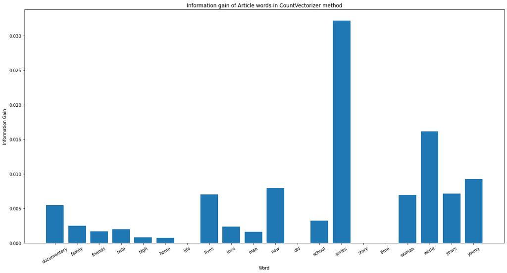

```python
import matplotlib.pyplot as plt

method1_article_plot = feature_selection.mutual_info_classif(X=method1_article_features_df, y=dataframe['type'])
plt.figure(figsize=(20,10))
plt.bar(method1_article_vectorizer.get_feature_names_out(), method1_article_plot)
plt.xticks(rotation=30, horizontalalignment="center")
plt.title("Information gain of Article words in CountVectorizer method")
plt.xlabel("Word")
plt.ylabel("Information Gain")
```

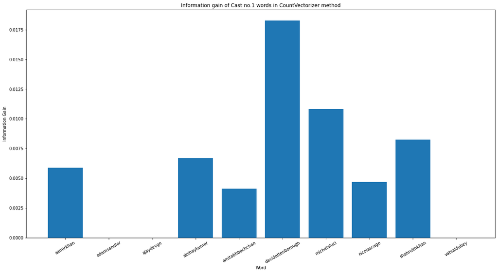

```python
method1_cast_plot = feature_selection.mutual_info_classif(X=method1_cast_features_df, y=dataframe['type'])
plt.figure(figsize=(20,10))
plt.bar(method1_cast_vectorizer.get_feature_names_out(), method1_cast_plot)
plt.xticks(rotation=30, horizontalalignment="center")
plt.title("Information gain of Cast no.1 words in CountVectorizer method")
plt.xlabel("Word")
plt.ylabel("Information Gain")
```

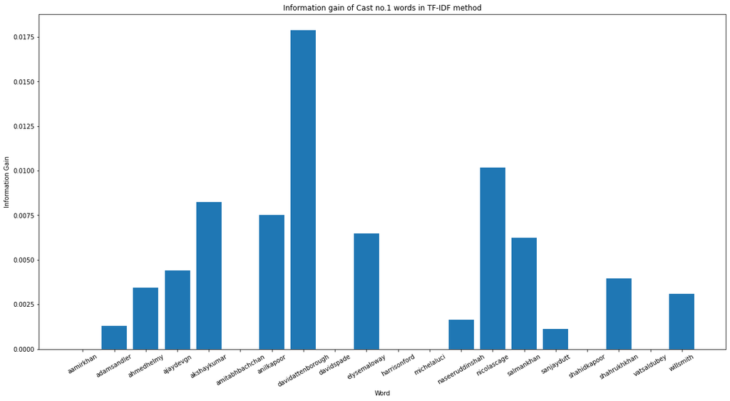

```python
method2_cast_plot = feature_selection.mutual_info_classif(X=method2_cast_features_df, y=dataframe['type'])

plt.figure(figsize=(20,10))
plt.bar(method2_cast_vectorizer.get_feature_names_out(), method2_cast_plot)
plt.xticks(rotation=30, horizontalalignment="center")
plt.title("Information gain of Cast no.1 words in TF-IDF method")
plt.xlabel("Word")
plt.ylabel("Information Gain")
```

Note that to run the "feature_selection.mutual_info_classif" function on our original dataframe, we first need to encode all the string!

```python
encoded_df = dataframe.copy()
for column in encoded_df:
    if(encoded_df[column].dtype == "object"):
        encoded_df[column] = label_encoder.fit_transform(encoded_df[column])

encoded_df
```

|  | type | country | release_year | genre no.1 | genre no.2 | genre no.3 | genre no.4 | genre no.5 | cast no.1 | cast no.2 | article |
| --- | --- | --- | --- | --- | --- | --- | --- | --- | --- | --- | --- |
| 0 | 0 | 608 | 0.989583 | 22 | 85 | 96 | 88 | 83 | 1487 | 1637 | 2476 |
| 1 | 1 | 430 | 1.000000 | 37 | 63 | 65 | 103 | 57 | 301 | 3856 | 1357 |
| 2 | 1 | 608 | 1.000000 | 20 | 33 | 61 | 86 | 32 | 5471 | 6976 | 3393 |
| 3 | 1 | 608 | 1.000000 | 24 | 46 | 98 | 38 | 85 | 1487 | 1637 | 4445 |
| 4 | 1 | 254 | 1.000000 | 37 | 49 | 62 | 103 | 46 | 4196 | 3268 | 4869 |
| ... | ... | ... | ... | ... | ... | ... | ... | ... | ... | ... | ... |
| 11054 | 1 | 608 | 0.781250 | 2 | 2 | 28 | 69 | 2 | 4669 | 7145 | 10893 |
| 11055 | 1 | 608 | 0.739583 | 18 | 13 | 28 | 84 | 12 | 5977 | 3353 | 8047 |
| 11056 | 1 | 608 | 0.927083 | 2 | 12 | 8 | 69 | 11 | 2550 | 4682 | 2549 |
| 11057 | 1 | 59 | 0.947917 | 2 | 12 | 50 | 69 | 11 | 4559 | 5708 | 2552 |
| 11058 | 1 | 608 | 0.864583 | 38 | 40 | 110 | 34 | 97 | 5184 | 1630 | 4234 |

11059 rows × 11 columns

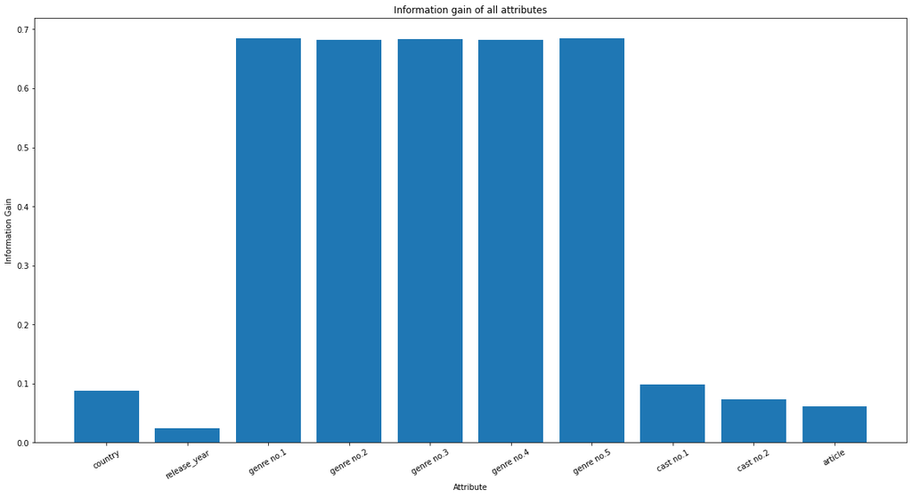

```python
attribute_list = list(encoded_df.columns)
attribute_list.remove("type")
all_attributes_plot = feature_selection.mutual_info_classif(X=encoded_df[attribute_list], y=encoded_df['type'])

plt.figure(figsize=(20,10))
plt.bar(attribute_list, all_attributes_plot)
plt.xticks(rotation=30, horizontalalignment="center")
plt.title("Information gain of all attributes")
plt.xlabel("Attribute")
plt.ylabel("Information Gain")
```

We can clearly see that the genres attributes have the highest information gain.

## $Part \hspace{3pt} \color{green}{Two}:$

```python
from sklearn import model_selection
from sklearn import preprocessing

encoded_method = method1_cast_df.copy() #change to method2_cast_df.copy() to use tf-idf method
for column in encoded_method:
    if(encoded_method[column].dtype == "object"):
        encoded_method[column] = label_encoder.fit_transform(encoded_method[column])

train_x, test_x, train_y, test_y = model_selection.train_test_split(encoded_method.loc[:, 'country':], method1_cast_df['type'],
                                                                    test_size=0.3, random_state=42)

# # label encode the target variable
# encoder = preprocessing.LabelEncoder()
# train_y = encoder.fit_transform(train_y)
# test_y = encoder.fit_transform(test_y)
```

```python
print("Number of train data is", len(train_x))
print("Number of test data is", len(test_x))
```

```
Number of train data is 7741
Number of test data is 3318
```

```python
encoded_method.loc[:, 'article':]
```

|  | article | documentary | family | friends | help | high | home | life | lives | love | ... | aamirkhan | adamsandler | ajaydevgn | akshaykumar | amitabhbachchan | davidattenborough | michelaluci | nicolascage | shahrukhkhan | vatsaldubey |
| --- | --- | --- | --- | --- | --- | --- | --- | --- | --- | --- | --- | --- | --- | --- | --- | --- | --- | --- | --- | --- | --- |
| 0 | 2476 | 0 | 0 | 0 | 1 | 0 | 0 | 1 | 0 | 0 | ... | 0 | 0 | 0 | 0 | 0 | 1 | 0 | 0 | 0 | 0 |
| 1 | 1357 | 0 | 0 | 0 | 0 | 0 | 0 | 0 | 0 | 0 | ... | 0 | 0 | 0 | 0 | 0 | 0 | 0 | 0 | 0 | 0 |
| 2 | 3393 | 0 | 1 | 0 | 0 | 0 | 0 | 0 | 0 | 0 | ... | 0 | 0 | 0 | 0 | 0 | 0 | 0 | 0 | 0 | 0 |
| 3 | 4445 | 0 | 0 | 0 | 0 | 0 | 0 | 0 | 0 | 0 | ... | 0 | 0 | 0 | 0 | 0 | 1 | 0 | 0 | 0 | 0 |
| 4 | 4869 | 0 | 0 | 1 | 0 | 0 | 0 | 1 | 0 | 0 | ... | 0 | 0 | 0 | 0 | 0 | 0 | 0 | 0 | 0 | 0 |
| ... | ... | ... | ... | ... | ... | ... | ... | ... | ... | ... | ... | ... | ... | ... | ... | ... | ... | ... | ... | ... | ... |
| 11054 | 10893 | 0 | 0 | 0 | 0 | 0 | 0 | 0 | 0 | 0 | ... | 0 | 0 | 0 | 0 | 0 | 0 | 0 | 0 | 0 | 0 |
| 11055 | 8047 | 0 | 0 | 0 | 0 | 1 | 0 | 0 | 0 | 0 | ... | 0 | 0 | 0 | 0 | 0 | 0 | 0 | 0 | 0 | 0 |
| 11056 | 2549 | 0 | 0 | 0 | 0 | 0 | 0 | 0 | 0 | 0 | ... | 0 | 0 | 0 | 0 | 0 | 0 | 0 | 0 | 0 | 0 |
| 11057 | 2552 | 0 | 0 | 0 | 0 | 0 | 0 | 0 | 0 | 0 | ... | 0 | 0 | 0 | 0 | 0 | 0 | 0 | 0 | 0 | 0 |
| 11058 | 4234 | 0 | 0 | 0 | 0 | 0 | 0 | 0 | 0 | 0 | ... | 0 | 0 | 0 | 0 | 0 | 0 | 0 | 0 | 0 | 0 |

11059 rows × 31 columns

```python
from sklearn.tree import DecisionTreeClassifier
from sklearn.metrics import accuracy_score,classification_report,confusion_matrix
clf_model = DecisionTreeClassifier(criterion="entropy", random_state=42, max_depth=9, min_samples_leaf=2, min_samples_split = 4)
clf_model.fit(train_x, train_y)
predict_y = clf_model.predict(test_x)
print("Accuracy is: ", accuracy_score(test_y, predict_y))
```

```
Accuracy is:  0.9888487040385775
```

As it is shown, we have reached 98% accuracy using the following hyperparameters:

$\color{blue}{max-depth:}$ The maximum depth of the tree. If None, then nodes are expanded until all leaves are pure or until all leaves contain less than min_samples_split samples.

We could've also used gridsearch to find the optimal values.

Further reading: $\href{https://medium.datadriveninvestor.com/an-introduction-to-grid-search-ff57adcc0998}{link}$

```python
from sklearn.model_selection import GridSearchCV

tree_para = {'criterion':['gini','entropy'],'max_depth':range(3, 15), 'min_samples_leaf':range(1, 4)}
grid_cv = GridSearchCV(DecisionTreeClassifier(), tree_para, cv=5)
grid_cv.fit(train_x, train_y)
grid_cv.best_params_
```

```
{'criterion': 'entropy', 'max_depth': 14, 'min_samples_leaf': 2}
```

We can also draw the confusion matrix as below:

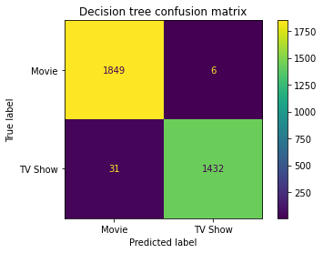

```python
from sklearn.datasets import make_classification
from sklearn.metrics import ConfusionMatrixDisplay
from sklearn.model_selection import train_test_split
from sklearn.svm import SVC

clf = SVC(random_state=0)
clf.fit(train_x, train_y)

ConfusionMatrixDisplay.from_predictions(test_y, predict_y)
plt.title("Decision tree confusion matrix")
plt.show()
```

1. Note that we've used 70 percent of out data for training. Notice what happens if we use 98 and 40 percent respectively:

```python
encoded_method_98 = method1_cast_df.copy() #change to method2_cast_df.copy() to use tf-idf method
for column in encoded_method_98:
    if(encoded_method_98[column].dtype == "object"):
        encoded_method_98[column] = label_encoder.fit_transform(encoded_method_98[column])

train_x_98, test_x_98, train_y_98, test_y_98 = model_selection.train_test_split(encoded_method_98.loc[:, 'country':],
                                                                                method1_cast_df['type'], test_size=0.02, random_state=42)

clf_model_98 = DecisionTreeClassifier(criterion="entropy", random_state=42, max_depth=9, min_samples_leaf=2, min_samples_split = 4)
clf_model_98.fit(train_x_98, train_y_98)
predict_y_98 = clf_model_98.predict(test_x_98)
print("Accuracy is: ", accuracy_score(test_y_98, predict_y_98))
```

```
Accuracy is:  0.990990990990991
```

```python
encoded_method_40 = method1_cast_df.copy() #change to method2_cast_df.copy() to use tf-idf method
for column in encoded_method_40:
    if(encoded_method_40[column].dtype == "object"):
        encoded_method_40[column] = label_encoder.fit_transform(encoded_method_40[column])

train_x_40, test_x_40, train_y_40, test_y_40 = model_selection.train_test_split(encoded_method_40.loc[:, 'country':],
                                                                                method1_cast_df['type'], test_size=0.60, random_state=42)

clf_model_40 = DecisionTreeClassifier(criterion="entropy", random_state=42, max_depth=9, min_samples_leaf=2, min_samples_split = 4)
clf_model_40.fit(train_x_40, train_y_40)
predict_y_40 = clf_model_40.predict(test_x_40)
print("Accuracy is: ", accuracy_score(test_y_40, predict_y_40))
```

```
Accuracy is:  0.9865883062085594
```

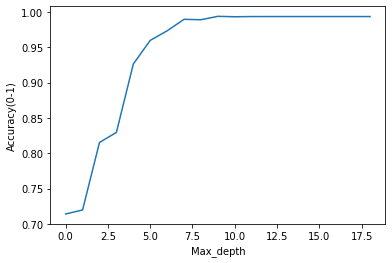

```python
vals = []
for depth in range(1, 20):
    clf_model_error = DecisionTreeClassifier(criterion="entropy", random_state=42, max_depth=depth, min_samples_leaf=2, min_samples_split = 4)
    clf_model_error.fit(train_x, train_y)
    predict_y = clf_model_error.predict(test_x)
    vals.append(accuracy_score(test_y, predict_y))

plt.plot(vals)
plt.xlabel('Max_depth')
plt.ylabel('Accuracy(0-1)')
plt.show()
```

## $Part \hspace{3pt} \color{green}{Three}:$

A simple random forest (without any hyperparameter tuning) would look like below:

```python
from sklearn.ensemble import RandomForestClassifier

random_forest = RandomForestClassifier()
random_forest.fit(train_x, train_y)
predict_forest = random_forest.predict(test_x)
print("Accuracy is: ", accuracy_score(test_y, predict_forest))
```

```
Accuracy is:  0.9945750452079566
```

Which is very accurate. We can examine the effect hyperparameters have on our accuracy:

1. n_estimators: number of trees in the foreset
2. max_features: max number of features considered for splitting a node
3. max_depth: max number of levels in each decision tree
4. min_samples_split: min number of data points placed in a node before the node is split
5. min_samples_leaf: min number of data points allowed in a leaf node

#### The effect of n_estimators on accuracy:

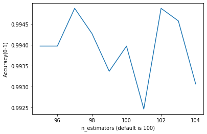

```python
n_estimators_vals = []
indices = []
for depth in range(95, 105):
    clf_model_n_estimators = RandomForestClassifier(n_estimators=depth)
    clf_model_n_estimators.fit(train_x, train_y)
    predict_y_n_estimators = clf_model_n_estimators.predict(test_x)
    n_estimators_vals.append(accuracy_score(test_y, predict_y_n_estimators))
    indices.append(depth)
plt.plot(indices, n_estimators_vals)
plt.xlabel('n_estimators (default is 100)')
plt.ylabel('Accuracy(0-1)')

plt.show()
```

#### The effect of max_features on accuracy:

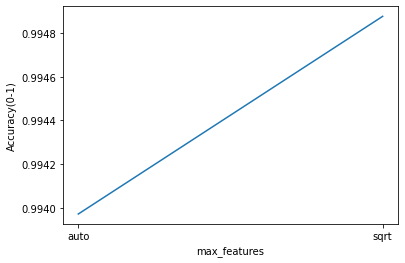

```python
max_features_vals = []
indices = []
for m_feature in ['auto', 'sqrt']:
    clf_model_max_features = RandomForestClassifier(max_features=m_feature)
    clf_model_max_features.fit(train_x, train_y)
    predict_y_max_features = clf_model_max_features.predict(test_x)
    max_features_vals.append(accuracy_score(test_y, predict_y_max_features))
    indices.append(m_feature)
plt.plot(indices, max_features_vals)
plt.xlabel('max_features')
plt.ylabel('Accuracy(0-1)')

plt.show()
```

We can see that random forest has higher accuracy in respect to the decision tree method. This is because random forest takes multiple decision trees into account and therefore has lower bias and higher variance. Similarly, decision tree has higher bias and lower variance. The optimal solution is inbetween these two states.

Note that:

$Total Error = Bias ^ 2 + Variance + Irreducible Error$

Further reading: $\href{https://towardsdatascience.com/understanding-the-bias-variance-tradeoff-165e6942b229}{link}$

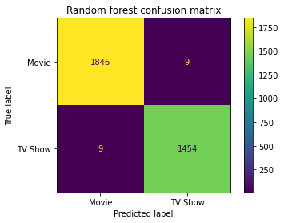

```python
# clf = SVC(random_state=0)
# clf.fit(train_x, train_y)

ConfusionMatrixDisplay.from_predictions(test_y, predict_forest)
plt.title("Random forest confusion matrix")
plt.show()
```

We can see that the plots confirm our interpretation too.